# Statistics with R

Cavan Donohoe

# Statistics with R

In this section, we will explore statistical analysis in R, covering descriptive statistics, hypothesis testing, and regression analysis.

## Descriptive Statistics

Descriptive statistics help you summarize and understand your data. Common descriptive statistics include measures of central tendency (mean, median, mode), measures of spread (variance, standard deviation, range), and graphical representations (histograms, box plots).

```r
# Descriptive statistics example
data <- c(12, 15, 18, 22, 25, 28, 31)

# Mean and median
mean_data <- mean(data)
mean_data
```

```
## [1] 21.57143
```

```r
median_data <- median(data)
median_data
```

```
## [1] 22
```

```r
# Variance and standard deviation
variance_data <- var(data)
variance_data
```

```
## [1] 48.28571
```

```r
sd_data <- sd(data)
sd_data
```

```
## [1] 6.948792
```

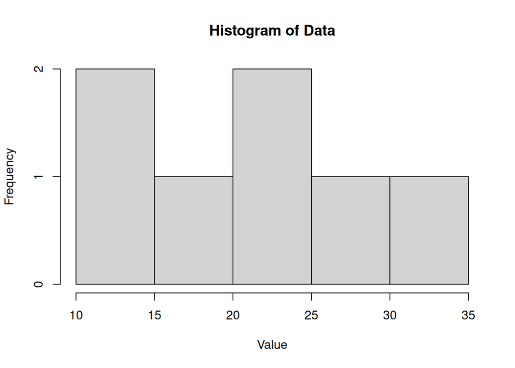

```r
# Histogram
hist(data, main = "Histogram of Data", xlab = "Value", ylab = "Frequency")
```

## Hypothesis Testing

Hypothesis testing is a crucial statistical technique to make inferences about populations based on sample data. In R, you can perform hypothesis tests for means, proportions, variances, and more. Here’s an example of a t-test for comparing two sample means:

```r
# Hypothesis testing example (t-test)
group1 <- c(10, 12, 14, 16, 18)
group2 <- c(14, 15, 16, 17, 18)

t_test_result <- t.test(group1, group2)
t_test_result
```

```
##
##  Welch Two Sample t-test
##
## data:  group1 and group2
## t = -1.2649, df = 5.8824, p-value = 0.2537
## alternative hypothesis: true difference in means is not equal to 0
## 95 percent confidence interval:
##  -5.887742  1.887742
## sample estimates:
## mean of x mean of y
##        14        16
```

## Regression Analysis

Regression analysis helps you model and analyze relationships between variables. You can perform linear regression, logistic regression, and other types of regression analysis in R. Here’s a simple linear regression example:

```r
# Linear regression example
x <- c(1, 2, 3, 4, 5)
y <- c(2, 4, 5, 4, 6)

linear_model <- lm(y ~ x)
summary(linear_model)
```

```
##
## Call:
## lm(formula = y ~ x)
##
## Residuals:
##    1    2    3    4    5
## -0.6  0.6  0.8 -1.0  0.2
##
## Coefficients:
##             Estimate Std. Error t value Pr(>|t|)
## (Intercept)   1.8000     0.9381   1.919   0.1508
## x             0.8000     0.2828   2.828   0.0663 .
## ---
## Signif. codes:  0 '***' 0.001 '**' 0.01 '*' 0.05 '.' 0.1 ' ' 1
##
## Residual standard error: 0.8944 on 3 degrees of freedom
## Multiple R-squared:  0.7273, Adjusted R-squared:  0.6364
## F-statistic:     8 on 1 and 3 DF,  p-value: 0.06628
```

In this section, we’ve covered the essentials of statistical analysis in R, including descriptive statistics, hypothesis testing, and regression analysis. These statistical tools are invaluable for drawing insights and making data-driven decisions.

Feel free to explore more advanced statistical techniques and datasets to deepen your understanding of statistics with R.

Free Lessons:

- [R Time Is Limited, Let’s Make the Most of It](https://cavandonohoe.github.io/learn_r.html)
- [Introduction to R](https://cavandonohoe.github.io/intro_to_r.html)
- [Basic Operations in R](https://cavandonohoe.github.io/basic_operations_r.html)
- [Data Manipulation](https://cavandonohoe.github.io/data_manipulation_r.html)
- [Data Visualization](https://cavandonohoe.github.io/data_visualization_r.html)
- [Statistics in R](https://cavandonohoe.github.io/statistics_with_r.html)

Feel free to contact me: